# Modèles Linéaires Généralisées

Papa Charles THIAM

2024-04-16

# 1 Packages

```r
library("ggplot2")
library('MASS')
library("skimr")
```

# 2 Rappels modèles linéaires

## 2.1 Exemple 1

Simulons 250 unités d’observation qui satisfaient nos conditions d’application qui sont :

1. La relation entre variable cible et variables dépendantes peut être décrite par une relation linéaire :
   $$Y = \beta_0 + \beta_1X_i + \epsilon$$
2. Le terme d’erreur $\epsilon$ a la même variance quelque soit la valeur de la variable explicative (c’est-à-dire, l’homoscédasticité), et les termes d’erreur ne sont pas corrélés entre les observations (donc, il n’y a pas d’autocorrélation) :

$$Var(\epsilon_i|X) = \sigma^2_\epsilon, \forall i = 1,...,N$$

$$Cov(\epsilon_i, \epsilon_j) = 0, i\neq j$$

3. Les résidus suivent une distribution normale :

$$\epsilon | X \sim \mathcal{N}(0, \sigma^2_\epsilon I)$$

Pour cet exemple, on prend $\epsilon_i | X \sim \mathcal{N}(0, 2^2)$, $\forall i$

```r
# Données simulées
nSamples <- 250
ID <- factor(c(seq(1:nSamples)))
PredVar <- runif(nSamples,
                  min = 0,
                  max = 50)
simNormData <- data.frame(
  ID = ID,
  PredVar = PredVar,
  RespVar = (2*PredVar +
               rnorm(nSamples,
                     mean = 0,
                     sd = 2)
             )
  )
head(simNormData)
```

```
##   ID  PredVar  RespVar
## 1  1 13.63168 23.33328
## 2  2 44.57661 88.37069
## 3  3 39.83687 78.48763
## 4  4 17.67831 38.09346
## 5  5 23.14130 43.01978
## 6  6 41.84310 84.64478
```

```r
# modéle linéaire
lm.simNormData <- lm(RespVar ~ PredVar,
                     data = simNormData)
```

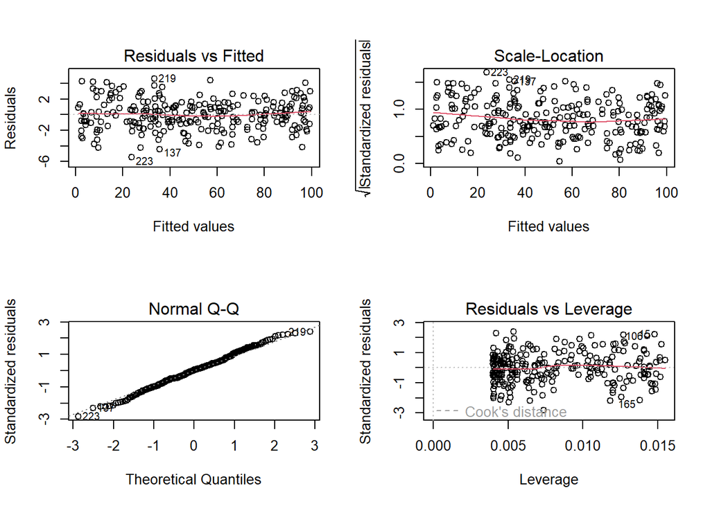

```r
# graphes des résidus
layout(matrix(c(1,2,3,4),2,2))
plot(lm.simNormData)
```

## 2.2 Exemple 2 : modèle linéraire général

Pour cet exemple, on cherche à répondre à la question : Est-ce que l’environnement permet de prédire l’abondance (Galuma), l’occurrence (pa), ou la proportion (prop) de Galumna sp.?

```r
# Chargement jeu de données
mites <- read.csv('mites.csv', stringsAsFactors = TRUE)
str(mites)
```

```
## 'data.frame':    70 obs. of  9 variables:
##  $ Galumna   : int  8 3 1 1 2 1 1 1 2 5 ...
##  $ pa        : int  1 1 1 1 1 1 1 1 1 1 ...
##  $ totalabund: int  140 268 186 286 199 209 162 126 123 166 ...
##  $ prop      : num  0.05714 0.01119 0.00538 0.0035 0.01005 ...
##  $ SubsDens  : num  39.2 55 46.1 48.2 23.6 ...
##  $ WatrCont  : num  350 435 372 360 204 ...
##  $ Substrate : Factor w/ 7 levels "Barepeat","Interface",..: 4 3 2 4 4 4 4 2 3 4 ...
##  $ Shrub     : Factor w/ 3 levels "Few","Many","None": 1 1 1 1 1 1 1 2 2 2 ...
##  $ Topo      : Factor w/ 2 levels "Blanket","Hummock": 2 2 2 2 2 2 2 1 1 2 ...
```

```r
# skim(mites)
```

Le jeu de données mites contient **70 échantillons de mousses et mites, 5 variables environmentales**, l’abondance de la mite Galumna sp., et l’abondance totale des mites.

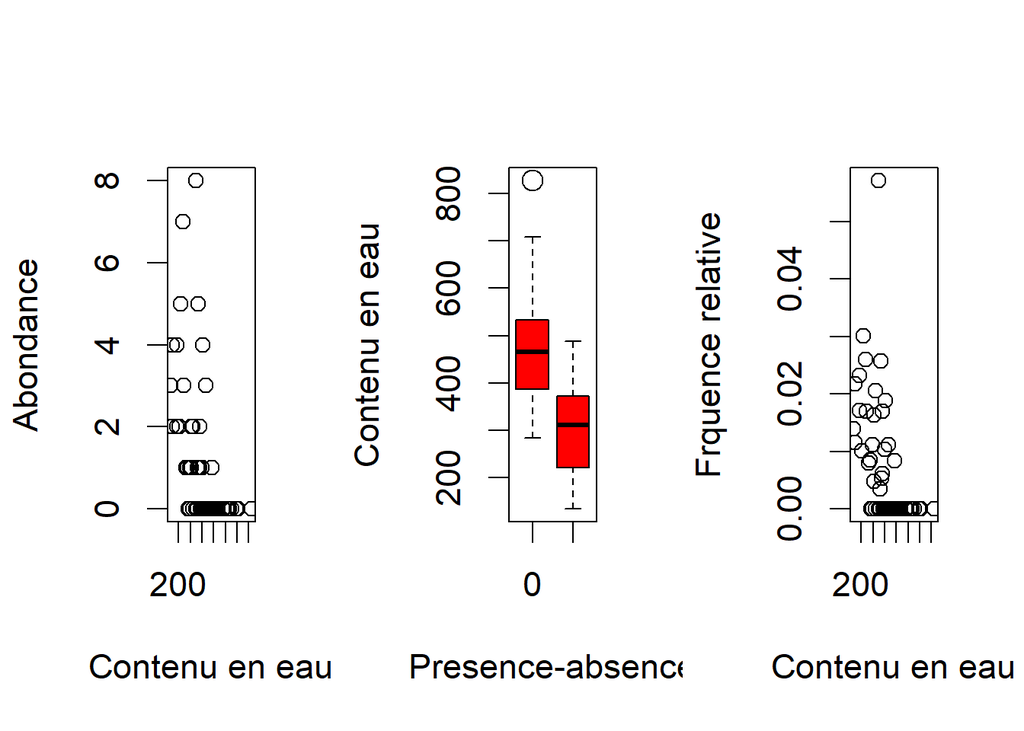

```r
par(mfrow = c(1, 3), cex = 1.4)
plot(Galumna ~ WatrCont, data = mites,
     xlab = 'Contenu en eau', ylab = 'Abondance')
boxplot(WatrCont ~ pa, data = mites,
        xlab = 'Presence-absence', ylab = 'Contenu en eau', col = 'red')
plot(prop ~ WatrCont, data = mites,
     xlab = 'Contenu en eau', ylab = 'Frquence relative')
```

A première vue, nous pouvons dire que la communauté de Galumna (abondance, occurence, et fréquence relative) varie en fonction du contenu en eau du sol. Utilisons des modèles linéaires (généraux) pour confirmer ou infirmer cette tendance.

```r
lm.abund <- lm(Galumna ~ WatrCont, data = mites)
summary(lm.abund)
```

```
##
## Call:
## lm(formula = Galumna ~ WatrCont, data = mites)
##
## Residuals:
##     Min      1Q  Median      3Q     Max
## -1.7210 -0.8236 -0.3270  0.3910  6.6772
##
## Coefficients:
##              Estimate Std. Error t value Pr(>|t|)
## (Intercept)  3.439349   0.555825   6.188 3.98e-08 ***
## WatrCont    -0.006045   0.001280  -4.723 1.21e-05 ***
## ---
## Signif. codes:  0 '***' 0.001 '**' 0.01 '*' 0.05 '.' 0.1 ' ' 1
##
## Residual standard error: 1.514 on 68 degrees of freedom
## Multiple R-squared:  0.247,  Adjusted R-squared:  0.2359
## F-statistic: 22.31 on 1 and 68 DF,  p-value: 1.206e-05
```

```r
lm.pa <- lm(pa ~ WatrCont, data = mites)
summary(lm.pa)
```

```
##
## Call:
## lm(formula = pa ~ WatrCont, data = mites)
##
## Residuals:
##      Min       1Q   Median       3Q      Max
## -0.61320 -0.30889 -0.05498  0.30247  0.80073
##
## Coefficients:
##               Estimate Std. Error t value Pr(>|t|)
## (Intercept)  1.1892142  0.1431306   8.309 6.03e-12 ***
## WatrCont    -0.0020263  0.0003296  -6.148 4.68e-08 ***
## ---
## Signif. codes:  0 '***' 0.001 '**' 0.01 '*' 0.05 '.' 0.1 ' ' 1
##
## Residual standard error: 0.3897 on 68 degrees of freedom
## Multiple R-squared:  0.3573, Adjusted R-squared:  0.3478
## F-statistic:  37.8 on 1 and 68 DF,  p-value: 4.677e-08
```

```r
lm.prop <- lm(prop ~ WatrCont, data = mites)
summary(lm.prop)
```

```
##
## Call:
## lm(formula = prop ~ WatrCont, data = mites)
##
## Residuals:
##       Min        1Q    Median        3Q       Max
## -0.010208 -0.004927 -0.002056  0.003240  0.049252
##
## Coefficients:
##               Estimate Std. Error t value Pr(>|t|)
## (Intercept)  2.020e-02  3.294e-03   6.133 4.98e-08 ***
## WatrCont    -3.516e-05  7.586e-06  -4.635 1.67e-05 ***
## ---
## Signif. codes:  0 '***' 0.001 '**' 0.01 '*' 0.05 '.' 0.1 ' ' 1
##
## Residual standard error: 0.008971 on 68 degrees of freedom
## Multiple R-squared:  0.2401, Adjusted R-squared:  0.2289
## F-statistic: 21.49 on 1 and 68 DF,  p-value: 1.665e-05
```

Tous les modèles sont significatifs. Mais…avons-nous respecté les conditions du modèle ?

Oops! On a un problème

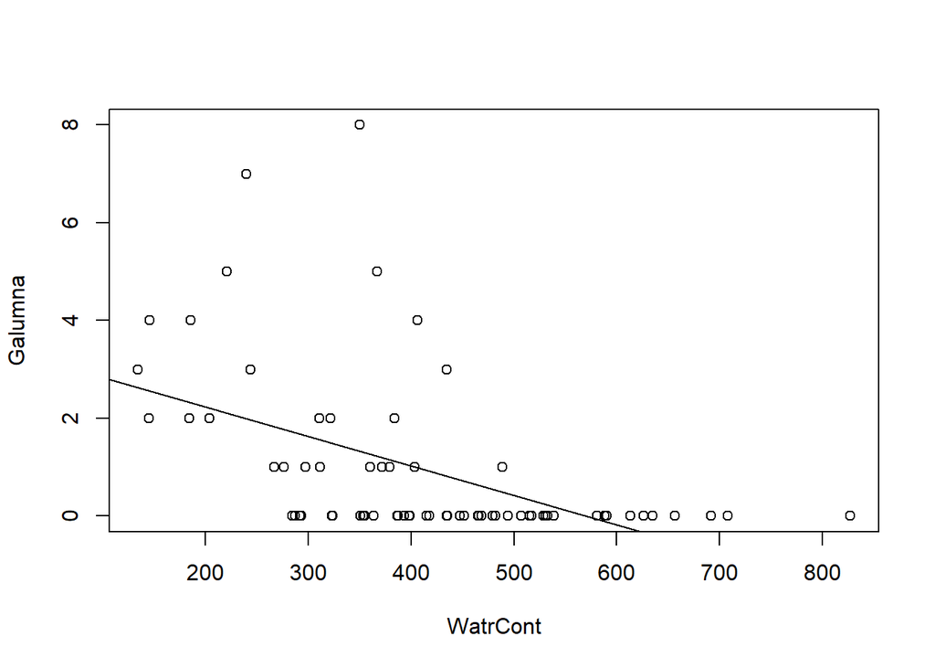

```r
plot(Galumna ~ WatrCont, data = mites)
abline(lm.abund)
```

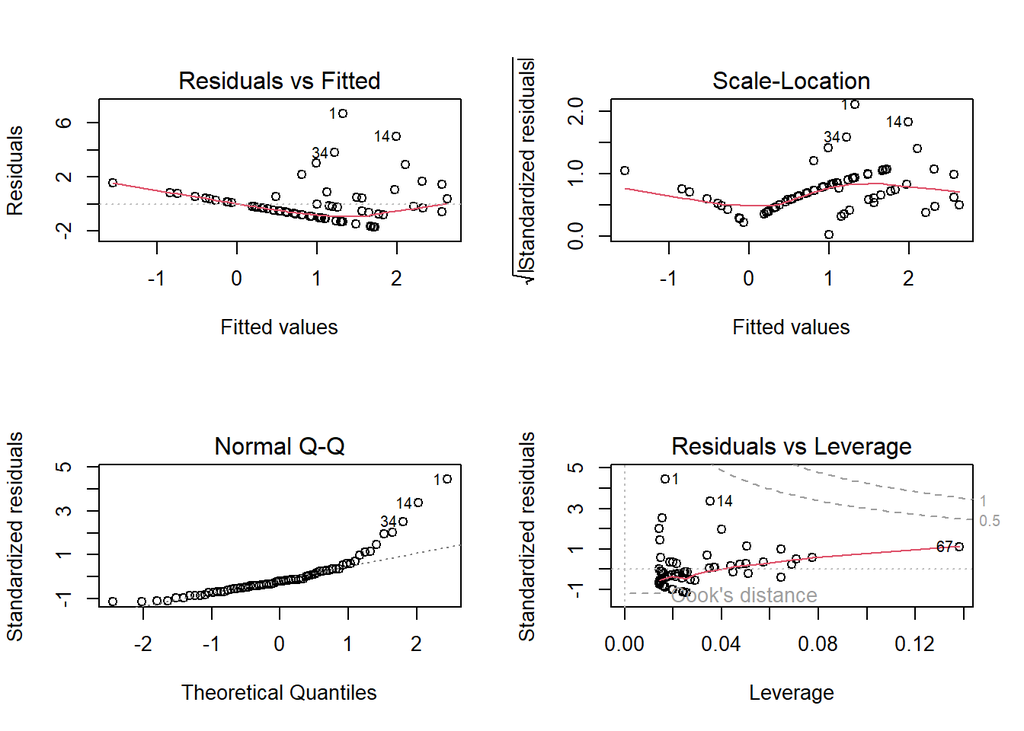

```r
# par(mfrow = c(2, 2), cex = 1.4)
layout(matrix(c(1,2,3,4),2,2))
plot(lm.abund)
```

Comment régler ces problèmes? Transformer ?

Souvent, les données ne respectent pas les conditions nous venons de voir, montrant des traces de non-normalité et/ou d’hétéroscédasticité.

On se fait souvent dire qu’il faut transformer nos données en utilisant des transformations logarithmiques, racine carrée, et cosinus.

Mais, les transformations ne règlent pas toujours le problème, et viennent avec quelques inconvénients : 1. Elles changent la variable réponse, ce qui peut compliquer l’interprétation; 2. Elles ne peuvent pas toujours améliorer la linéarité et l’homogénité de la variance en même temps; 3. Les limites de l’espace d’échantillonage changent.

# 3 GLM

## 3.1 Exercice 1

```r
logit.reg <- glm(pa ~ WatrCont + Topo, data=mites,
                 family = binomial(link = "logit"))

summary(logit.reg)
```

```
##
## Call:
## glm(formula = pa ~ WatrCont + Topo, family = binomial(link = "logit"),
##     data = mites)
##
## Deviance Residuals:
##     Min       1Q   Median       3Q      Max
## -2.0387  -0.5589  -0.1594   0.4112   2.0252
##
## Coefficients:
##              Estimate Std. Error z value Pr(>|z|)
## (Intercept)  4.464402   1.670622   2.672 0.007533 **
## WatrCont    -0.015813   0.004535  -3.487 0.000489 ***
## TopoHummock  2.090757   0.735348   2.843 0.004466 **
## ---
## Signif. codes:  0 '***' 0.001 '**' 0.01 '*' 0.05 '.' 0.1 ' ' 1
##
## (Dispersion parameter for binomial family taken to be 1)
##
##     Null deviance: 91.246  on 69  degrees of freedom
## Residual deviance: 48.762  on 67  degrees of freedom
## AIC: 54.762
##
## Number of Fisher Scoring iterations: 6
```

**Interpréter les coefficients de glm()**

```r
logit.reg <- glm(pa ~ WatrCont + Topo, data=mites,
                 family = binomial(link = "logit"))
summary(logit.reg)$coefficients
```

```
##                Estimate  Std. Error   z value     Pr(>|z|)
## (Intercept)  4.46440199 1.670622482  2.672299 0.0075333598
## WatrCont    -0.01581255 0.004535069 -3.486728 0.0004889684
## TopoHummock  2.09075654 0.735348234  2.843220 0.0044660283
```

L’interprétation directe des coefficients dans le modèle logit est délicate en raison de la fonction de lien. Si le lien est identité, l’interprétation est beaucoup plus facile.

Supposons que nous avons un résultat binaire $y$ et deux covariables $x_1$ et $x_2$ (et une constante). La probabilité d’un résultat positif ($y = 1$) est donnée par:

$$Pr(y=1) = p = g^{-1}(\beta_0 + x_{1i}\beta_1 + x_{2i}\beta_2)$$

avec $g$ la fonction de lien.

### 3.1.1 Lien d’identité

Pour le lien d’identité, l’interprétation est simple. Pour l’augmentation d’une unité en $x_1$, $\beta_1$ entraîne une différence constante dans le résultat.

$$\Delta y_i = [\beta_0 + (x_{1i} + 1)\beta_1 + x_{2i}\beta_2] - (\beta_0
+ x_{1i}\beta_1 + x_{2i}\beta_2)$$

$\Delta y_i = \beta_1$

### 3.1.2 Lien logit

$$logit\left(\frac{p}{1-p}\right) = \beta_0 + x_{1i}\beta_1 +
x_{2i}\beta_2$$

$$Pr(y=1) = p = \frac{exp(\beta_0 + x_{1i}\beta_1 + x_{2i}\beta_2)}{1 +
exp(\beta_0 + x_{1i}\beta_1 + x_{2i}\beta_2)}$$

On a, après calcul :

$\Delta y_i = exp(\beta_1)$

Ainsi, on peut dire lorsque x augmente d’une unité, la probabilité augmente d’un facteur de $exp(\beta_1)$

Par exemple, pour une augmentation (ou une diminution) d’une unité de contenu en eau, on peut obtenir la probabilité de la présence de mites.

```r
exp(logit.reg$coefficient[2])
```

```
##  WatrCont
## 0.9843118
```

Ce qu’on appelle $odds = \frac{p}{1-p}$. Quand $odds=1$, la probabilité d’observer l’évènement Y est égale à la probabilité de ne pas l’observer (i.e. $p = 0.5$, donc $0.5/(1−0.5)=1$).

Lorsque $odds<1$, il faut prendre l’inverse (i.1 divisé par les odds). L’interprétation est alors de savoir quelle est la **moindre** probabilité d’observer l’évènement d’intérêt.

Pour la teneur en eau, le $odds$ est de 0.984. L’inverse est 1.0159. i.e., il y a une augmentation d’une unité de la teneur en eau diminue la probabilité d’observer Galumna sp. de 1.0159.

Nous pouvons obtenir une variation en pourcentage comme ci-dessous : (1.0159 − 1)∗100=1.59. Il y a une diminution de 1.59 de la probabilité d’observer Galumna sp. avec une augmentation d’une unité de la teneur en eau.

**Pouvoir prédictif et ajustement du modèle**

Nous pouvons dans ce cas un **pseudo-**$R^2$, un concept analogue au $R^2$ pour les modèles estimés par maximisation de la vraisemblance.

Nous pouvons calculer le **pseudo-**$R^2$ de McFadden (1973) :

$$\text{pseudo-}R^2 = \frac{\text{déviance nulle} - \text{déviance
résiduelle}}{\text{déviance nulle}}$$

**NB** : La déviance unitaire est une mesure de la distance entre $y$ et $\mu$.

$$d(y, y) = 0 \quad\text{et}\quad d(y,\mu)>0 \quad \forall y\neq\mu$$

La déviance totale d’un modèle avec prédictions $\hat\mu$ de l’observation $y$ est la sommé de ses déviances unitaires :
$$D(y, \hat{\mu}) = \sum_i d(y_i, \hat\mu_i)$$

Maintenant, la déviance d’un mod_le avec des prédictions $\hat\mu = E[Y|\hat\theta_0]$ peut être définie par sa vraisemblance :

$$D(y, \hat{\mu}) = 2\left(\log(p(y|\hat\theta_s)) -
\log(p(y|\hat\theta_0))\right)$$

avec les paramètres ajustés dans le modèle réduit $(\hat\theta_0)$ et saturé $(\hat\theta_s)$.

La **déviance résiduelle** est définie comme 2 fois le logarithme du ratio de vraisemblance du modèle complet par rapport au modèle réduit. (La fonction ci-dessous est exactement la même que ci-dessus !)

$$D(y, \hat{\mu}) = 2\left(\log(p(\text{modèle saturé})) -
\log(p(\text{modèle réduit}))\right)$$

Et, la **déviation nulle** est définie comme 2 fois le logarithme du ratio de vraisemblance du modèle complet par rapport au modèle nul (où les prédicteurs sont fixés à 1).

$$D(y, \hat{\mu}) = 2\left(\log(p(\text{modèle saturé})) -
\log(p(\text{modèle nul}))\right)$$

Le **modèle nul** est un modèle sans variables explicatives. Par exemple :

```r
null.model <- glm(Response.variable ~ 1, family = binomial)
```

Le **modèle à déviance saturée (ou totale)** est ici un modèle avec toutes les variables explicatives.

```r
full.model <- glm(response.variable ~ ., family = binomial)
```

Dans `R`, nous pouvons extraire les déviances résiduelles et nulles directement à partir de l’`objet glm`

```r
objects(logit.reg)
```

```
##  [1] "aic"               "boundary"          "call"
##  [4] "coefficients"      "contrasts"         "control"
##  [7] "converged"         "data"              "deviance"
## [10] "df.null"           "df.residual"       "effects"
## [13] "family"            "fitted.values"     "formula"
## [16] "iter"              "linear.predictors" "method"
## [19] "model"             "null.deviance"     "offset"
## [22] "prior.weights"     "qr"                "R"
## [25] "rank"              "residuals"         "terms"
## [28] "weights"           "xlevels"           "y"
```

Ainsi, on peut avoir la valeur de **pseudo-**$R^2$ :

```r
pseudoR2 <- (logit.reg$null.deviance - logit.reg$deviance) / logit.reg$null.deviance
pseudoR2
```

```
## [1] 0.4655937
```

Donc, le modèle explique 46.6% de la variabilité des données.

Comme $R^2$, pseudo-$R^2$ est sensible au nombre de prédicateurs. Pour pallier ce problème, nous pouvons utiliser un pseudo-$R^2$ de McFadden ajusté, qui pénalise pour le nombre de prédicateurs :

$$R^2_{adj} = 1 - \frac{\log L(M) - K}{\log L(M_null)}$$
où $k$ correspond au nombre supplémentaire de prédicateurs par rapport au modèle nul.

**NB** : La qualité d’ajustement des modèles de régression logistique peut être exprimée par des variantes de statistiques pseudo-R2, telles que les mesures de Maddala (1983) ou de Cragg et Uhler (1970).

Lorsqu’on parle de régressions logistiques, les valeurs faibles de $R^2$ sont souvent courantes.

La fonction `DescTools::PseudoR2()` calcule plusieurs pseudo-R2.

La fonction `R DescTools::PseudoR2()` permet de calculer plusieurs pseudo-R2. En spécifiant `which = all`, calculez toutes les statistiques en même temps.

```r
logit.reg <- glm(pa ~ WatrCont + Topo,
                 data = mites, family = binomial(link = "logit"))
DescTools::PseudoR2(logit.reg, which = "all")
```

```
##        McFadden     McFaddenAdj        CoxSnell      Nagelkerke   AldrichNelson
##       0.4655937       0.3998373       0.4549662       0.6245898       0.3776866
## VeallZimmermann           Efron McKelveyZavoina            Tjur             AIC
##       0.6674318       0.5024101       0.7064093       0.5114661      54.7623962
##             BIC          logLik         logLik0              G2
##      61.5078819     -24.3811981     -45.6229593      42.4835224
```

## 3.2 GLM et données de proportions

Parfois, les données de proportions sont plus similaires à une régression logistiques que ce que nous pensons…

En comptes discrets, nous pouvons, par exemple, mesurer le nombre de présences d’individus par rapport au nombre total de populations échantillonnées.

Nous obtiendrons ainsi un nombre proportionnel de “succès” dans l’oberservation des individus en divisant les comptes par les comptes totaux.

Dans `glm()`, nous devons fournir des poids a priori si la variable de réponse est la proportion de succès

Les proportions peuvent être codées en fournissant le nombre de succès et des poids a priori dans la fonction :

```r
prop.reg <- glm(cbind(Galumna, totalabund - Galumna) ~ Topo + WatrCont,
                data = mites,
                family = binomial)
```

Les poids peuvent aussi être spécifiés dans `glm()`:

```r
prop.reg2 <- glm(prop ~ Topo + WatrCont,
                 data = mites,
                 family = binomial,
                 weights = totalabund)
```

## 3.3 GLM avec des données d’abondance

Les **données d’abondance** font référence à des données qui fournissent des informations sur la quantité ou la fréquence de quelque chose. En général, ces données indiquent la présence ou la quantité relative d’un élément spécifique dans un ensemble de données.

Importons le jeu de données `faramea.csv`.

```r
faramea <- read.csv('faramea.csv', header = TRUE)
str(faramea)
```

```
## 'data.frame':    43 obs. of  9 variables:
##  $ X                   : chr  "B0" "B49" "p1" "p2" ...
##  $ UTM.EW              : num  625754 626654 614857 613985 614674 ...
##  $ UTM.NS              : num  1011569 1011969 1031786 1030725 1023802 ...
##  $ Precipitation       : num  2530 2530 2993 3072 3007 ...
##  $ Elevation           : int  120 120 20 100 180 180 40 30 60 50 ...
##  $ Age                 : int  3 3 2 3 1 1 2 2 1 3 ...
##  $ Age.cat             : chr  "c3" "c3" "c2" "c3" ...
##  $ Geology             : chr  "Tb" "Tb" "Tc" "Tc" ...
##  $ Faramea.occidentalis: int  14 7 0 0 2 1 0 0 2 0 ...
```

Le nombre d’arbres de l’espèce Faramea occidentalis a été compté dans 43 quadrats sur l’île de Barro Colorado (Panama). Des données environnementales, comme l’élévation et la précipitation ont aussi été mesurées.

Examinons maintenant à quoi ressemble la distribution du nombre d’arbres par transect.

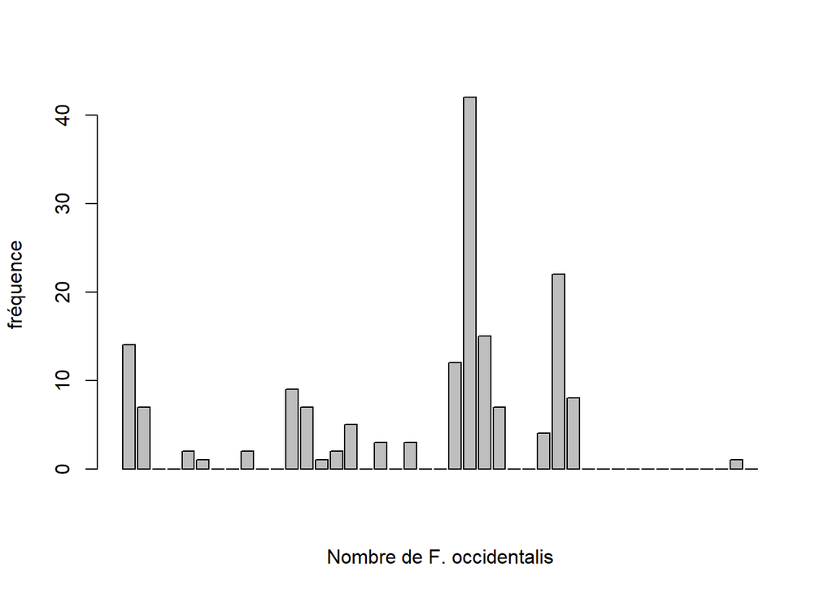

```r
barplot(faramea$Faramea.occidentalis,
        ylab = "fréquence",
        xlab = "Nombre de F. occidentalis")
```

L’élévation influence-t-elle l’abondance de F. occidentalis ?

[figure not shown]

```r
plot(faramea$Faramea.occidentalis, faramea$Elevation,
     ylab = "Nombre de F.occidentalis",
     xlab = "Elevation(m)")
```

Pas évident à première vue, passons à la modélisation.

La distribution de Poisson est plus adéquate. En effet, elle spécifie la probabilité d’une variable aléatoire discrète Y. D’après le diagramme en barre de la variable cible ci-haut, on a à faire avec une variable de comptage, du coup discrète.

**Quelques propriétés de la loi**
$$f(y, \mu) = Pr(Y=y) = \frac{\mu^y\times e^{-\mu}}{y!}$$
$$E(Y) = Var(Y) = \mu$$

- $\mu$ est le paramètre de la distribution
- Elle spécifie la probabilité pour des valeurs entières uniquement
- $P(Y<0)=0$
- moyenne = variance (permet l’hétérogénéité)

**Que se cache-t-il derrière un GLM Poisson**

On cherche à modéliser la valeur de $\mu$ en fonction des différentes variables explicatives.

1. On suppose que $y\sim Poisson(\mu_i)$
   $$f(y_i, \mu_i) = \frac{\mu_i^{y_i}\times e^{-\mu_i}}{y_i!}$$

$\mu$ correspond au nombre attendu d’individus

2. On spécifie le prédicteur linéaire comme dans un modèle linéaire

$$\alpha + \beta\times \text{Elevation}_i$$

3. La fonction de lien entre la moyenne de $Y_i$ et la partie systématique est une fonction logarithmique et est écrité comme suit :

$$\log(\mu_i) = \alpha + \beta\times \text{Elevation}_i$$
ou
$$\mu_i = e^{\alpha + \beta\times \text{Elevation}_i}$$

Ceci montre que l’impact de chaque variable explicative est multiplicatif. Augmenter l’élévation de un augmente $\mu$ par le facteur $\exp(\beta_{\text{Elevation}})$.  
Si $\beta_j = 0$, alors $\exp(\beta_j) = 1$ et $\mu$ n’est pas lié à $x_j$. Si $\beta_j>0$ alors $\mu$ augmente si $x_j$ augmente et vice-versa.

**Application dans R**

La fonction `glm()` permet de spécifier un GLM Poisson comme suit :

```r
glm.poisson = glm(Faramea.occidentalis ~ Elevation,
                  data = faramea, family = poisson)
summary(glm.poisson)
```

```
##
## Call:
## glm(formula = Faramea.occidentalis ~ Elevation, family = poisson,
##     data = faramea)
##
## Deviance Residuals:
##     Min       1Q   Median       3Q      Max
## -3.3319  -2.7509  -1.5451   0.1139  11.3995
##
## Coefficients:
##               Estimate Std. Error z value Pr(>|z|)
## (Intercept)  1.7687001  0.1099136  16.092  < 2e-16 ***
## Elevation   -0.0027375  0.0006436  -4.253 2.11e-05 ***
## ---
## Signif. codes:  0 '***' 0.001 '**' 0.01 '*' 0.05 '.' 0.1 ' ' 1
##
## (Dispersion parameter for poisson family taken to be 1)
##
##     Null deviance: 414.81  on 42  degrees of freedom
## Residual deviance: 388.12  on 41  degrees of freedom
## AIC: 462.01
##
## Number of Fisher Scoring iterations: 10
```

L’argument `family` spécifie le type de distribution et la fonction lien.

On a :
$$\log(\mu_i) = 1.769 - 0.0027\times\text{Elevation}_i$$
ou
$$\mu_i = e^{1.769 - 0.0027\times\text{Elevation}_i}$$
Rappelez vous que pour estimer les paramètres inconnus, l’estimation par maximum de vraisemblance est utilisée.

La déviance résiduelle est approximativement la différence entre la vraisemblance d’un modèle saturé ($n$ paramètres pour chaque observation) et le modèle complet ($p$ paramètres) :

$$\text{Res dev} = 2\left(\log(L(y; y)) -\log(L(y;\mu))\right)$$

Dans un GLM Poisson, la déviance résiduelle doit être égale au nombre de degrés de liberté résiduels.

Notre déviance résiduelle est beaucoup plus grande que les degrés de liberté de notre modèle!

**La surdispersion**

Pour une distribution Poisson $var[y]=\mu$, . En pratique, cependant, on constate que la variance des données dépasse souvent $\mu$, indiquant une surdispersion dans les paramètres du modèle.

La surdispersion est due au fait que la moyenne $\mu$ varie intrinsèquement, même lorsque toutes les variables explicatives sont fixes, ou parce que le les événements qui sont comptés sont corrélés positivement.

**Problème** : Les tests sur les variables explicatives apparaîtront généralement plus significatifs et les intervalles de confiance des paramètres seront plus étroits que les données ne le justifierait!

Quand la déviance résiduelle est supérieure au nombre de degrés de liberté résiduels, le modèle est **surdispersé**.

On peut calculer le paramètre de surdispersion ($\phi$) par :
$$\phi = \frac{\text{Déviance résiduelle}}{\text{Degrés de liberté
résiduels}}$$

Si, $\phi$ est plus que 1, alors nous devrons l’estimer avec :
$$\hat\phi = \frac{1}{n-k}\sum\frac{\left(Y_i -
\hat\mu_i\right)^2}{\hat\mu_i}$$

Sur `R`, on peut obtenir $\phi$ par :

```r
sum(residuals(ton_obj_glm, type="pearson")^2)/df.residual(ton_obj_glm)
```

**Solutions**

1. Corriger la surdispersion en utilisant un **GLM quasi-Poisson**
2. Choisir une autre distribution comme la **negative binomiale**

### 3.3.1 GLM quasi-Poisson

La variance du modèle tient compte de la surdispersion en ajoutant le paramètre de surdispersion :
$$Var(Y_i) = \phi\times\mu_i$$
où $\phi$ est le paramètre de dispersion. Il sera estimé avant les paramètres.

L’espérance, le prédicteur linéaire et la fonction de lien restent les mêmes.

**NB** : Cette correction n’affecte pa l’etimation des paramètres, mais leur significativité, car les écarts-types des paramètres seront multipliés par $\sqrt{\phi}$. De ce fait, certains p-values marginalement significatives peuvent devenir non significatives.

Sous `R`, on peut mettre le modèle de Poisson précédent à jour ou créer un nouveau GLM à l’aide de la famille `quasipoisson`

```r
glm.quasipoisson = update(glm.poisson,
                          family = quasipoisson)
```

```r
glm.quasipoisson = glm(Faramea.occidentalis ~ Elevation,
                       data = faramea,
                       family=quasipoisson)
summary(glm.quasipoisson)
```

```
##
## Call:
## glm(formula = Faramea.occidentalis ~ Elevation, family = quasipoisson,
##     data = faramea)
##
## Deviance Residuals:
##     Min       1Q   Median       3Q      Max
## -3.3319  -2.7509  -1.5451   0.1139  11.3995
##
## Coefficients:
##              Estimate Std. Error t value Pr(>|t|)
## (Intercept)  1.768700   0.439233   4.027 0.000238 ***
## Elevation   -0.002738   0.002572  -1.064 0.293391
## ---
## Signif. codes:  0 '***' 0.001 '**' 0.01 '*' 0.05 '.' 0.1 ' ' 1
##
## (Dispersion parameter for quasipoisson family taken to be 15.96936)
##
##     Null deviance: 414.81  on 42  degrees of freedom
## Residual deviance: 388.12  on 41  degrees of freedom
## AIC: NA
##
## Number of Fisher Scoring iterations: 10
```

On peut remarquer que les écarts-types des paramètres sont multipliés par $\sqrt{\phi} = 4$.

Pour tester l’effet de l’élévation par une analyse de déviance :

```r
null.model <- glm(Faramea.occidentalis ~ 1,
                  data = faramea,
                  family = quasipoisson)
anova(null.model, glm.quasipoisson, test = "Chisq")
```

```
## Analysis of Deviance Table
##
## Model 1: Faramea.occidentalis ~ 1
## Model 2: Faramea.occidentalis ~ Elevation
##   Resid. Df Resid. Dev Df Deviance Pr(>Chi)
## 1        42     414.81
## 2        41     388.12  1   26.686   0.1961
```

### 3.3.2 GLM binomiale negative

Quand la surdispersion est élevée ($\phi > 15$), une distribution binomiale négative est plus appropriée.

- La distribution a deux paramètres $\mu$ et $k$ pour le contrôle de la dispersion (plus la persion est forte, plus k est petit);
- C’est une combinaison de deux distributions (**Poisson** et **gamma**)
- Les $Y_i$ suivent une distribution de Poisson dont la moyenne $\mu$ suit une distribution Gamma.

Le valeurs prédites suivent :
$$E(Y_i) = \mu_i$$
et la fonction de variance:
$$Var(Y_i) = \mu_i + \frac{\mu_i^2}{k}$$

Notons que la distribution binomiale n’est pas dans la fonction `glm()`, donc il faut installer et charger le package `MASS`

```r
glm.negbin <- MASS::glm.nb(Faramea.occidentalis ~ Elevation, data = faramea)
summary(glm.negbin)
```

```
##
## Call:
## MASS::glm.nb(formula = Faramea.occidentalis ~ Elevation, data = faramea,
##     init.theta = 0.2593107955, link = log)
##
## Deviance Residuals:
##      Min        1Q    Median        3Q       Max
## -1.36748  -1.17564  -0.51338  -0.05226   2.25716
##
## Coefficients:
##              Estimate Std. Error z value Pr(>|z|)
## (Intercept)  2.369226   0.473841    5.00 5.73e-07 ***
## Elevation   -0.007038   0.002496   -2.82  0.00481 **
## ---
## Signif. codes:  0 '***' 0.001 '**' 0.01 '*' 0.05 '.' 0.1 ' ' 1
##
## (Dispersion parameter for Negative Binomial(0.2593) family taken to be 1)
##
##     Null deviance: 41.974  on 42  degrees of freedom
## Residual deviance: 36.343  on 41  degrees of freedom
## AIC: 182.51
##
## Number of Fisher Scoring iterations: 1
##
##
##               Theta:  0.2593
##           Std. Err.:  0.0755
##
##  2 x log-likelihood:  -176.5090
```

Le modèle final est :
$$\mu_i = e^{\text{2.3692263}+\text{-0.0070381}\times\text{Elevation}_i}$$

```r
pp <- predict(glm.negbin,
              newdata = data.frame(Elevation = 1:800),
              se.fit = TRUE)
linkinv <- family(glm.negbin)$linkinv ## fonction lien-inverse
pframe$pred0 <- pp$fit
pframe$pred <- linkinv(pp$fit)
sc <- abs(qnorm((1-0.95)/2))  ## Normal approx. to likelihood
pframe <- transform(pframe,
                    lwr = linkinv(pred0-sc*pp$se.fit),
                    upr = linkinv(pred0+sc*pp$se.fit))
# sinon, utiiser predict() avec type="response"
plot(faramea$Elevation, faramea$Faramea.occidentalis,
     ylab = 'Number of F. occidentalis', xlab = 'Elevation(m)')
lines(pframe$pred, lwd = 2)
lines(pframe$upr, col = 2, lty = 3, lwd = 2)
lines(pframe$lwr, col = 2, lty = 3, lwd = 2)
```

[output not shown]

## 3.4 Defi

### 3.4.1 Défi 1

En utilisant le jeu de données bacteria, spécifiez un modèle de la présence de H. influenzae en fonction du traitement et de la semaine de test.

```r
library(MASS)
data(bacteria)
str(bacteria)
```

```
## 'data.frame':    220 obs. of  6 variables:
##  $ y   : Factor w/ 2 levels "n","y": 2 2 2 2 2 2 1 2 2 2 ...
##  $ ap  : Factor w/ 2 levels "a","p": 2 2 2 2 1 1 1 1 1 1 ...
##  $ hilo: Factor w/ 2 levels "hi","lo": 1 1 1 1 1 1 1 1 2 2 ...
##  $ week: int  0 2 4 11 0 2 6 11 0 2 ...
##  $ ID  : Factor w/ 50 levels "X01","X02","X03",..: 1 1 1 1 2 2 2 2 3 3 ...
##  $ trt : Factor w/ 3 levels "placebo","drug",..: 1 1 1 1 3 3 3 3 2 2 ...
```

Commençons avec un modèle complet et trouvez le modèle le plus parcimonieux.

```r
model.bact1 <- glm(y ~ trt * week, data = bacteria, family = binomial)
model.bact2 <- glm(y ~ trt + week, data = bacteria, family = binomial)
model.bact3 <- glm(y ~ week, data = bacteria, family = binomial)
anova(model.bact1, model.bact2, model.bact3, test = "LRT")
```

```
## Analysis of Deviance Table
##
## Model 1: y ~ trt * week
## Model 2: y ~ trt + week
## Model 3: y ~ week
##   Resid. Df Resid. Dev Df Deviance Pr(>Chi)
## 1       214     203.12
## 2       216     203.81 -2  -0.6854  0.70984
## 3       218     210.91 -2  -7.1026  0.02869 *
## ---
## Signif. codes:  0 '***' 0.001 '**' 0.01 '*' 0.05 '.' 0.1 ' ' 1
```

### 3.4.2 Defi 2

**Questions**

1. En utilisant le modèle créé avec le jeu de données bacteria, évaluez le pouvoir prédictif et l’ajustement de ce modèle.
2. Comment améliorer le pouvoir explicatif du modèle?

**Solutions**

1. En utilisant le modèle créé avec le jeu de données bacteria, évaluez le pouvoir prédictif et l’ajustement de ce modèle.

```r
null.d <- model.bact2$null.deviance
resid.d <- model.bact2$deviance
bact.pseudoR2 <- (null.d - resid.d) / null.d
bact.pseudoR2
```

```
## [1] 0.0624257
```

2. Comment améliorer le pouvoir explicatif du modèle?

Ajouter des variables explicatives pertinentes pourrait certainement augmenter le pouvoir explicatif du modèle.

Mais, n’ayez pas peur de résultats non-significatifs!